# Introduction to Machine Learning in R

Evan Muzzall and Chris Kennedy

11/25/2018

# Introduction

Visit the UC Berkeley [D-Lab](http://dlab.berkeley.edu/) to learn more about our services and resources, including the [Machine Learning Working Group](http://dlab.berkeley.edu/working-groups/machine-learning-working-group-0).

## Resources

*An Introduction to Statistical Learning - with Applications in R (2013)* by Gareth James, Daniela Witten, Trevor Hastie, Robert Tibshirani. Springer: New York. [Amazon](https://www.amazon.com/Introduction-Statistical-Learning-Applications-Statistics/dp/1461471370) or [free PDF](http://www-bcf.usc.edu/~gareth/ISL/). We encourage you to support the authors by purchasing their textbook!

## Package installation

The following packages are required to run the code in this workshop:

```r
if (FALSE) {
  # Run these lines manually (once) to install the necessary packages.

  # Install packages from CRAN.
  install.packages(c(# Algorithms
                     "class", "gbm", "randomForest", "ranger", "rpart", "xgboost",
                     # Visualization
                     "ggplot2", "rpart.plot",
                     # Machine learning frameworks
                     "caret", "SuperLearner",
                     # R utility packages
                     "devtools", "dplyr",
                     # Misc
                     "gmodels", "mlbench", "pROC", "chemometrics"))

  # Install packages not on CRAN or with old version on CRAN.
  devtools::install_github(c("ck37/ck37r"))
}

# Hide the many messages and possible warnings from loading all these packages.
suppressMessages(suppressWarnings({
  library(caret)        # createDataPartition creates a stratified random split
  library(chemometrics) # knnEval algorithm
  library(ck37r)        # impute_missing_values, SuperLearner helpers
  library(class)        # K nearest neighbors
  library(devtools)     # Allows installing packages from github
  library(dplyr)        # Data cleaning
  library(gbm)          # Gradient boosted machines
  library(ggplot2)      # Graphics
  library(gmodels)      # Nice cross tabulations
  library(magrittr)     # Pipes %>% for data cleaning, installed by dplyr.
  library(pROC)         # Compute and plot AUC
  library(randomForest) # random forest algorithm
  library(rpart)        # Decision tree algorithm
  library(rpart.plot)   # Decision tree plotting
  library(SuperLearner) # Ensemble methods
}))
```

## Brief history of machine learning

Machine learning evolved from scientific pursuits in statistics, computer science, information theory, artificial intelligence, and pattern recognition.

How to define machine learning?  
1) **In general:** algorithms, computers, and other machines that can “learn” without direct input from a human programmer.  
2) **Practically:** sets of tools for investigating/modeling/understanding data.  
3) **Specifically:** (see below)

A proto-example:  
- [Pascal’s calculator](http://history-computer.com/MechanicalCalculators/Pioneers/Pascal.html)

Rapid advances:  
- [McCulloch Pitts neuron model](http://wwwold.ece.utep.edu/research/webfuzzy/docs/kk-thesis/kk-thesis-html/node12.html)  
- [Turing test](http://www.jstor.org/stable/pdf/2251299.pdf)  
- [Rosenblatt’s perceptron](http://www.ling.upenn.edu/courses/cogs501/Rosenblatt1958.pdf)  
- Samuels and the game of checkers

Modern topics:  
- [Turing Test: 50 years later](http://www.cs.bilkent.edu.tr/~akman/jour-papers/mam/mam2000.pdf)  
- [computer vision](http://www.sciencedirect.com/science/article/pii/S1071581916301264)  
- [data cleaning](http://www.betterevaluation.org/sites/default/files/data_cleaning.pdf)  
- [robotics](https://arxiv.org/abs/1708.04677)  
- [cloud computing](https://arxiv.org/abs/1707.07452)

The importance of statistics:  
- [Welling’s commentary](https://www.ics.uci.edu/~welling/publications/papers/WhyMLneedsStatistics.pdf)  
- [Srivastava’s discussion](https://www.analyticsvidhya.com/blog/2015/07/difference-machine-learning-statistical-modeling/)  
- [Breiman’s take](https://projecteuclid.org/euclid.ss/1009213726)

Seek “actionable insight”:  
- [“actionable insight”](https://www.techopedia.com/definition/31721/actionable-insight)

# Supervised machine learning

Selecting a machine learning algorithm depends on the characteristics of the problem being investigated - there is no “best” method applicable to all cases. Machine learning is generally divided into three broad classes of learning: [supervised](https://en.wikipedia.org/wiki/Supervised_learning), [unsupervised](https://en.wikipedia.org/wiki/Unsupervised_learning), and [reinforcement](https://en.wikipedia.org/wiki/Reinforcement_learning). In this workshop we will focus on classification, although a simple regression example is provided as a bonus challenge.

The syntax for supervised machine learning algorithms can be thought of like this:

Y ~ X<sub>1</sub> + X<sub>2</sub> + X<sub>3</sub>… X<sub>n</sub>

Y is the dependent/response/target/outcome variable  
X are the independent/input/predictor/feature variables

Supervised machine learning methods learn a target function $f$ that best maps X to Y based on a set of [training data](https://en.wikipedia.org/wiki/Training,_test,_and_validation_sets).

Our function would look like this: $y = f(X) + \epsilon$, where $f$ is some function that relates our X predictor variables to Y in an unknown way thus we must estimate it. Epsilon $\epsilon$ is the random error, is independent of X, and averages to zero. Therefore, we can predict Y using $\hat{y} = \hat{f}(X)$ for new data (call the test dataset) and evaluate how well the algorithm learned the target function when introduced to new data.

**How to define machine learning? (revisited)**  
More specifically, we can think of machine learning as a bunch of methods to estimate $f$!

##### Classification or regression?

**Classification** is used when the Y outcome variable is categorical/discrete. Binary examples generally refer to a yes/no situation where a 1 is prediction of the “yes” category and 0 as the “no”. Classification models the probability that the outcome variable is 1 based on the covariates: $Pr(Y = 1 | X)$. This can be extended to multi-level classification as well.

**Regression** is used when the target Y outcome variable is continuous. Regression models the conditional expectation (conditional mean) of the outcome variable given the covariates: $E(Y | X)$. See the bonus challenge for a regression example.

##### Data preprocessing

A longstanding first step is to split a dataset into **“training”** and **“test”** subsets. A training sample usually consists of a majority of the original dataset so that an algorithm can learn the model. The remaining portion of the dataset is designated to the test sample to evaluate model performance on data the model has not yet seen. **Missing data should be handled** before the splitting process commences.

##### Model performance

**Performance metrics** are used to see how well a model predicts a specified outcome on training and test datasets.

A model that performs poorly on the training dataset is **underfit** because it is not able to discern relationships between the X and Y variables.

A model that performs well on the training dataset but poorly on the test dataset is said to be **overfit** because the model performed worse than expected when given new data. To some extent the patterns found in the training data may have been random noise and therefore, by random chance, are different in the test data.

##### Common performance metrics

- Accuracy
- Mean squared error
- Sensitivity and specificity
- Area under the ROC curve (AUC)

# Workshop goals

##### General goals

1. Learn the basics of using five machine learning algorithms in R:
- k-nearest neighbor
- decision tree
- random forest
- boosting
- SuperLearner
- linear regression (bonus)
2. Examine the performance of these models
3. Vizualize important information:
- knn accuracy tables
- decision trees
- random forest variable importance
- AUC from different boosting models
- SuperLearner cross-validated risk
4. Simultaneously compare multiple algorithms in an ensemble

##### Specific goals

Use the `PimaIndiansDiabetes2` dataset from the [`mlbench` package](https://cran.r-project.org/web/packages/mlbench/mlbench.pdf) to investigate the following questions:

1. **Binary classification examples:** How reliably can different machine learning algorithms predict a person’s diabetes status using the other variables?
2. **Bonus regression example:** How well can a person’s age be predicted using the other variables?

What are these other variables? Let’s load the data and find out!

# Load the data

Load the `PimaIndiansDiabetes2` and `iris` datasets

```r
library(mlbench)

# Load the PimaIndiansDiabetes2 dataset.
data("PimaIndiansDiabetes2")

# Read background information and variable descriptions.
?PimaIndiansDiabetes2

# Rename the dataset to something simpler (pidd = "Pima Indians Diabetes Dataset").
pidd = PimaIndiansDiabetes2

# View the structure of pidd.
str(pidd)
```

```
## 'data.frame':    768 obs. of  9 variables:
##  $ pregnant: num  6 1 8 1 0 5 3 10 2 8 ...
##  $ glucose : num  148 85 183 89 137 116 78 115 197 125 ...
##  $ pressure: num  72 66 64 66 40 74 50 NA 70 96 ...
##  $ triceps : num  35 29 NA 23 35 NA 32 NA 45 NA ...
##  $ insulin : num  NA NA NA 94 168 NA 88 NA 543 NA ...
##  $ mass    : num  33.6 26.6 23.3 28.1 43.1 25.6 31 35.3 30.5 NA ...
##  $ pedigree: num  0.627 0.351 0.672 0.167 2.288 ...
##  $ age     : num  50 31 32 21 33 30 26 29 53 54 ...
##  $ diabetes: Factor w/ 2 levels "neg","pos": 2 1 2 1 2 1 2 1 2 2 ...
```

```r
# Also load iris dataset for challenge questions.
data(iris)
str(iris)
```

```
## 'data.frame':    150 obs. of  5 variables:
##  $ Sepal.Length: num  5.1 4.9 4.7 4.6 5 5.4 4.6 5 4.4 4.9 ...
##  $ Sepal.Width : num  3.5 3 3.2 3.1 3.6 3.9 3.4 3.4 2.9 3.1 ...
##  $ Petal.Length: num  1.4 1.4 1.3 1.5 1.4 1.7 1.4 1.5 1.4 1.5 ...
##  $ Petal.Width : num  0.2 0.2 0.2 0.2 0.2 0.4 0.3 0.2 0.2 0.1 ...
##  $ Species     : Factor w/ 3 levels "setosa","versicolor",..: 1 1 1 1 1 1 1 1 1 1 ...
```

```r
# Background info/variable descriptions.
?iris
```

```
## Help on topic 'iris' was found in the following packages:
##
##   Package               Library
##   datasets              /Library/Frameworks/R.framework/Versions/3.5/Resources/library
##   h2o                   /Users/evan.admin/Library/R/3.5/library
##
##
## Using the first match ...
```

# Data preprocessing

Data peprocessing is an integral first step in machine learning workflows. Because different algorithms sometimes require the moving parts to be coded in slightly different ways, always make sure you research the algorithm you want to implement so that you properly setup your Y and X variables and appropriately split your data into training and test sets if neeeded.

One additional preprocessing aspect to consider: datasets that contain factor (categorical) features should typically be expanded out into numeric indicators (this is often referred to as [one-hot encoding](https://hackernoon.com/what-is-one-hot-encoding-why-and-when-do-you-have-to-use-it-e3c6186d008f). You can do this manually with the `model.matrix` R function. This makes it easier to code a variety of algorithms to a dataset as many algorithms handle factors poorly (decision trees being the main exception). Doing this manually is always good practice. However, functions like `lm` will internally expand factor variables such as the `diabetes` factor predictor into numeric indicators.

> NOTE: Keep in mind that training/test dataset splitting is common, but not always preferred. We will introduce you to cross-validation in the second half of this workshop where *all* the data are used and multiple training/testing splits are utilized.

# Handling missing data

Missing values need to be handled somehow. Listwise deletion (deleting any row with at least one missing case) is common but this method throws out a lot of useful information. Many advocate for mean imputation, but arithmetic means are sensitive to outliers. Still, others advocate for Chained Equation/Bayesian/Expectation Maximization imputation (e.g., the [mice](http://www.stefvanbuuren.nl/publications/mice%20in%20r%20-%20draft.pdf) and [Amelia II](https://gking.harvard.edu/amelia) R packages).

Median imputation is also useful, but k-nearest neighbor (knn) imputation is demonstrated below:

```r
# First, count the number of missing values across variables in our pidd dataset
colSums(is.na(pidd))
```

```
## pregnant  glucose pressure  triceps  insulin     mass pedigree      age
##        0        5       35      227      374       11        0        0
## diabetes
##        0
```

```r
# Then, compute the proportion of missing values across all data cells in pidd
sum(is.na(pidd)) / (nrow(pidd) * ncol(pidd)) # ~9% of data points are missing
```

```
## [1] 0.0943287
```

Neither the “diabetes” nor “age” columns have any missing values, so we can go ahead and impute the whole dataset!

> Note: view the help files for `?impute_missing_values` to see that the data are centered and scaled when “knn” is specified as the argument to the “type” parameter. You can also center and scale your data manually using R’s builtin `scale` function - type `?scale` to learn more.

```r
result = ck37r::impute_missing_values(pidd,
                               verbose = TRUE,
                               type = "knn")
```

```
## Found 5 variables with NAs.
## Generating missingness indicators.
## Generating 5 missingness indicators.
## Checking for collinearity of indicators.
## Indicators added (5): miss_glucose, miss_pressure, miss_triceps, miss_insulin, miss_mass
```

```r
# Use the imputed dataframe.
pidd = result$data

# view new columns
str(pidd)
```

```
## 'data.frame':    768 obs. of  14 variables:
##  $ pregnant     : num  0.64 -0.844 1.233 -0.844 -1.141 ...
##  $ glucose      : num  0.862 -1.201 2.008 -1.07 0.501 ...
##  $ pressure     : num  -0.0327 -0.5173 -0.6788 -0.5173 -2.6171 ...
##  $ triceps      : num  0.558 -0.0146 0.1381 -0.5873 0.558 ...
##  $ insulin      : num  0.92 -0.761 0.359 -0.518 0.105 ...
##  $ mass         : num  0.165 -0.846 -1.322 -0.629 1.537 ...
##  $ pedigree     : num  0.468 -0.365 0.604 -0.92 5.481 ...
##  $ age          : num  1.4251 -0.1905 -0.1055 -1.0409 -0.0205 ...
##  $ diabetes     : Factor w/ 2 levels "neg","pos": 2 1 2 1 2 1 2 1 2 2 ...
##  $ miss_glucose : int  0 0 0 0 0 0 0 0 0 0 ...
##  $ miss_pressure: int  0 0 0 0 0 0 0 1 0 0 ...
##  $ miss_triceps : int  0 0 1 0 0 1 0 1 0 1 ...
##  $ miss_insulin : int  1 1 1 0 0 1 0 1 0 1 ...
##  $ miss_mass    : int  0 0 0 0 0 0 0 0 0 1 ...
```

```r
# No more missing data and missingness indicators have been added as columns!
colSums(is.na(pidd))
```

```
##      pregnant       glucose      pressure       triceps       insulin
##             0             0             0             0             0
##          mass      pedigree           age      diabetes  miss_glucose
##             0             0             0             0             0
## miss_pressure  miss_triceps  miss_insulin     miss_mass
##             0             0             0             0
```

# Defining Y outcome vectors and X feature dataframes

##### Classification setup

Assign the outcome variable to its own vector for **CLASSIFICATION tasks:** in this workshop, k-nearest neighbor, decision tree, random forest, gradient boosting, and SuperLearner algorithms. However, keep in mind that these algorithms can also perform regression!

```r
# View pidd variable names
names(pidd)
```

```
##  [1] "pregnant"      "glucose"       "pressure"      "triceps"
##  [5] "insulin"       "mass"          "pedigree"      "age"
##  [9] "diabetes"      "miss_glucose"  "miss_pressure" "miss_triceps"
## [13] "miss_insulin"  "miss_mass"
```

```r
# 1) Define Y for classification (has diabetes? "pos" or "neg")
y_fac = pidd$diabetes
head(y_fac, n = 20)
```

```
##  [1] pos neg pos neg pos neg pos neg pos pos neg pos neg pos pos pos pos
## [18] pos neg pos
## Levels: neg pos
```

```r
# 2) Then, convert "pos" to 1 and "neg" to 0. Many algorithms expect 1's for the positive class and 0's for the negative class.
y = as.integer(y_fac == "pos")
table(y, y_fac, useNA = "ifany")
```

```
##    y_fac
## y   neg pos
##   0 500   0
##   1   0 268
```

```r
# 3) Finally, define the X feature/predictor dataframe that excludes the Y outcome.
features = subset(pidd, select = -diabetes)

# Diabetes column has been successfully removed.
names(features)
```

```
##  [1] "pregnant"      "glucose"       "pressure"      "triceps"
##  [5] "insulin"       "mass"          "pedigree"      "age"
##  [9] "miss_glucose"  "miss_pressure" "miss_triceps"  "miss_insulin"
## [13] "miss_mass"
```

We then can take the simple approach to data splitting and divide our data into training and test sets; 70% of the data will be assigned to the training set and the remaining 30% will be assigned to the holdout, or test, set.

```r
# Set seed for reproducibility.
set.seed(1)

# Create a stratified random split.
training_rows = caret::createDataPartition(y, p = 0.70, list = FALSE)

train_x = features[training_rows, ] # partition training dataset
test_x = features[-training_rows, ] # partition test dataset

train_label = y[training_rows] # partition training Y vector labels
test_label = y[-training_rows] # partition test Y vector labels

# lengths of our Y label vectors and the number of rows in our training dataframes are the same for both training and test sets!
dim(train_x)
```

```
## [1] 538  13
```

```r
length(train_label)
```

```
## [1] 538
```

```r
dim(test_x)
```

```
## [1] 230  13
```

```r
length(test_label)
```

```
## [1] 230
```

# 1. k-nearest neighbor (knn)

The k-nearest neighbor (knn) algorithm is a good machine learning start point because it makes no assumptions about the underlying distribution of the data. To classify a data point, knn uses the characteristics of the points around it to determine how to classify it. [Euclidean distances](https://en.wikipedia.org/wiki/Euclidean_distance) between points are used in this example.

“k” is the number of neighbors used to classify the point in question. Choosing a proper “k” is integral to finding the best-performing model. **Large k-values** could be bad because the class with the largest size might win regardless of the influence of closer points. **Small k-values** might also be bad because neighboring points might become overly influential.

##### 1.1 knn - selecting a starting k value

Different methods exist for choosing a start point for “k”. Let’s use the square root of the number of rows in the training datset:

```r
(sqrt_rows = round(sqrt(nrow(train_x)))) # 23
```

```
## [1] 23
```

Fit the model! Our goal is to predict the classification accuracy of our Y variable (whether or not a person has diabetes based on the other `train_x` predictor variables; 1 = yes/pos, 0 = no/neg:

```r
# Set our seed because ties are randomly broken in knn.
set.seed(1)
knn_result = class::knn(train = train_x, test = test_x,
                 cl = train_label, k = sqrt_rows, prob = TRUE)
```

Using accuracy as our performance metric, compute a contingency table to see how well the model predicted yes and no:

```r
gmodels::CrossTable(x = test_label, y = knn_result,
                    # Unfortunately, proportions default to TRUE so we can set them to FALSE to get simpler results.
                    chisq = FALSE,
                    prop.chisq = FALSE,
                    prop.r = FALSE,
                    prop.c = FALSE,
                    prop.t = FALSE)
```

```
##
##
##    Cell Contents
## |-------------------------|
## |                       N |
## |-------------------------|
##
##
## Total Observations in Table:  230
##
##
##              | knn_result
##   test_label |         0 |         1 | Row Total |
## -------------|-----------|-----------|-----------|
##            0 |       123 |        25 |       148 |
## -------------|-----------|-----------|-----------|
##            1 |        41 |        41 |        82 |
## -------------|-----------|-----------|-----------|
## Column Total |       164 |        66 |       230 |
## -------------|-----------|-----------|-----------|
##
##
```

```r
# or
caret::confusionMatrix(knn_result, factor(test_label))
```

```
## Confusion Matrix and Statistics
##
##           Reference
## Prediction   0   1
##          0 123  41
##          1  25  41
##
##                Accuracy : 0.713
##                  95% CI : (0.6499, 0.7706)
##     No Information Rate : 0.6435
##     P-Value [Acc > NIR] : 0.01534
##
##                   Kappa : 0.3461
##  Mcnemar's Test P-Value : 0.06484
##
##             Sensitivity : 0.8311
##             Specificity : 0.5000
##          Pos Pred Value : 0.7500
##          Neg Pred Value : 0.6212
##              Prevalence : 0.6435
##          Detection Rate : 0.5348
##    Detection Prevalence : 0.7130
##       Balanced Accuracy : 0.6655
##
##        'Positive' Class : 0
##
```

```r
# Compute accuracy - how did we do?
mean(test_label == knn_result)
```

```
## [1] 0.7130435
```

How did it do?

##### 1.2 knn - improving performance metrics

Two common ways of improving model performance are to 1) standardize the data so that scale does not unduly influence classification, and 2) change the k-value.

Remember that our knn imputation from the `ck37::impute_missing_values` function above has already centered and scaled our data for us so we can focus on changing the value of `k`.

> Note: More practice is always good for data preprocessing and splitting. In your own time, consider repeating all steps above, except use “standard” instead of “knn” as the method inside `impute_missing_values` function in the “Handling missing data” section above. Do your results change? Why or why not?

##### 1.3 knn - improving performance metrics - change k-value

It also helps to investigate the cross-validated accuracy for multiple k-values at once to see which is ideal. Plot the cross-validated error rates:

```r
set.seed(1)
knn_k = chemometrics::knnEval(X = subset(pidd, select = -diabetes), grp = y_fac, train = training_rows,
                knnvec = c(1, 2, 3, 4, 5, 10, 20, 30, 40, 50),
                kfold = 20, las = 2)
```

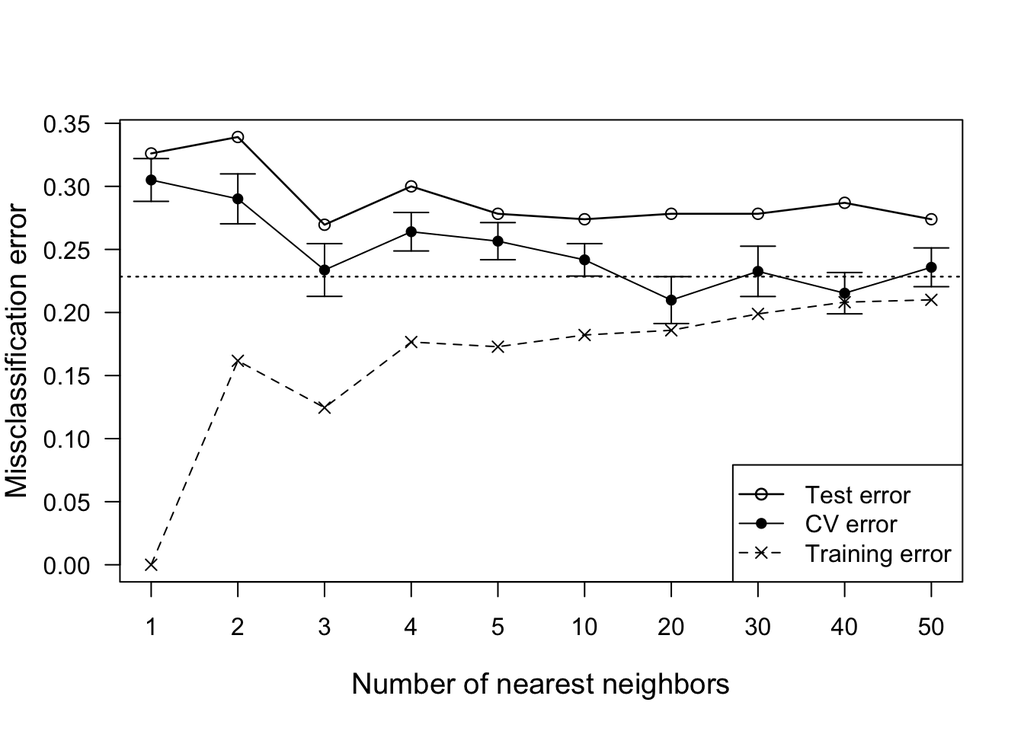

A combination of scaling the data and searching for the best cross-validated “k” can help maximize the accuracy of k-nearest neighbors. We don’t have time to cover today but integrating kernels, alternative distance metrics, and feature selection are additional ways to maximize the performance.

See [page 105 of Wu et al’s 2018 paper](https://www.sciencedirect.com/science/article/pii/S2352914817301405) to see how our KNN stacks up to their comparative KNN reference study.

**Big question 1:** What might you conclude about the k-nearest neighbors algorithm and this particular dataset? (see the solutions file for an answer)

##### Challenge 1

Using what you learned above, classify knn predictive accuracies of the `Species` variable in the “iris” dataset.

# 2. Decision trees

Decision trees are recursive partitioning methods that divide the predictor spaces into simpler regions and can be visualized in a tree-like structure. Decision trees attempt to classify data by dividing it into subsets according to a Y output variable and based on some predictors.

Let’s see how a decision tree classifies diabetes status from our dataset.

Note that we do not have to use `model.matrix` for our decision tree algorithm here because it can work with factor variables directly:

```r
tree = rpart::rpart(y ~ ., data = features,
             # Use method = "anova" for a continuous outcome.
             method = "class",
             # Can use "gini" for gini coefficient.
             parms = list(split = "information"))

# Here is the text-based display of the decision tree. Yikes!  :^(
print(tree)
```

```
## n= 768
##
## node), split, n, loss, yval, (yprob)
##       * denotes terminal node
##
##   1) root 768 268 0 (0.651041667 0.348958333)
##     2) glucose< 0.1903755 484  93 0 (0.807851240 0.192148760)
##       4) mass< -0.8631731 123   1 0 (0.991869919 0.008130081) *
##       5) mass>=-0.8631731 361  92 0 (0.745152355 0.254847645)
##        10) age< -0.4031286 187  22 0 (0.882352941 0.117647059) *
##        11) age>=-0.4031286 174  70 0 (0.597701149 0.402298851)
##          22) insulin< -0.3817966 65  11 0 (0.830769231 0.169230769) *
##          23) insulin>=-0.3817966 109  50 1 (0.458715596 0.541284404)
##            46) pedigree< -0.820564 20   3 0 (0.850000000 0.150000000) *
##            47) pedigree>=-0.820564 89  33 1 (0.370786517 0.629213483)
##              94) age>=1.977777 7   1 0 (0.857142857 0.142857143) *
##              95) age< 1.977777 82  27 1 (0.329268293 0.670731707) *
##     3) glucose>=0.1903755 284 109 1 (0.383802817 0.616197183)
##       6) mass< -0.3620892 76  24 0 (0.684210526 0.315789474)
##        12) glucose< 0.7798506 41   6 0 (0.853658537 0.146341463) *
##        13) glucose>=0.7798506 35  17 1 (0.485714286 0.514285714)
##          26) miss_insulin>=0.5 21   8 0 (0.619047619 0.380952381) *
##          27) miss_insulin< 0.5 14   4 1 (0.285714286 0.714285714) *
##       7) mass>=-0.3620892 208  57 1 (0.274038462 0.725961538)
##        14) glucose< 1.172834 116  45 1 (0.387931034 0.612068966)
##          28) age< -0.2330639 50  23 0 (0.540000000 0.460000000)
##            56) pressure>=0.04803814 27   8 0 (0.703703704 0.296296296)
##             112) mass< 1.349105 18   2 0 (0.888888889 0.111111111) *
##             113) mass>=1.349105 9   3 1 (0.333333333 0.666666667) *
##            57) pressure< 0.04803814 23   8 1 (0.347826087 0.652173913) *
##          29) age>=-0.2330639 66  18 1 (0.272727273 0.727272727) *
##        15) glucose>=1.172834 92  12 1 (0.130434783 0.869565217) *
```

Although interpreting the text can be intimidating, a decision tree’s main strength is its tree-like plot, which is much easier to interpret.

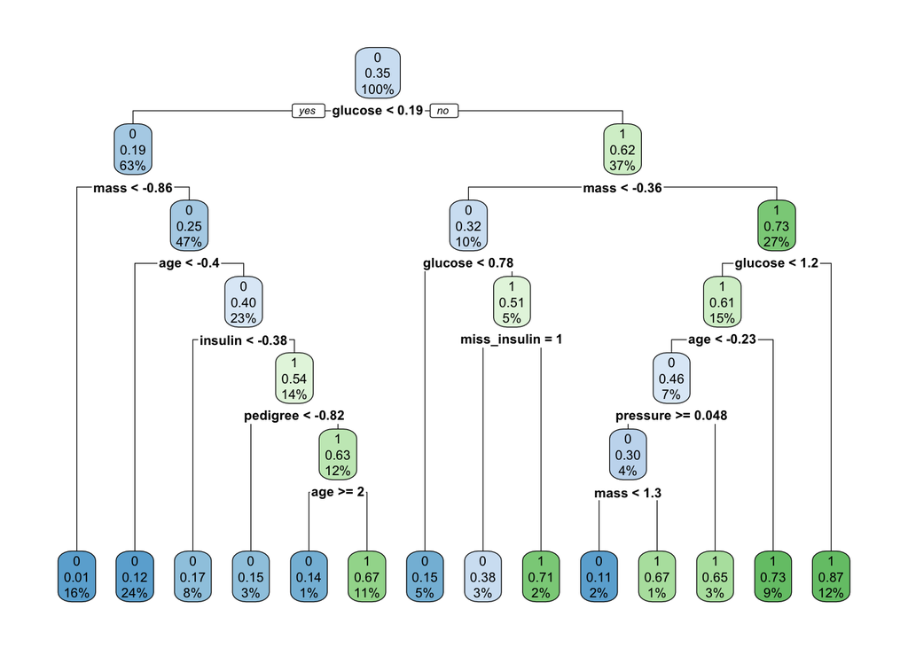

```r
rpart.plot::rpart.plot(tree)
```

We can also look inside of `tree` to see what we can unpack. “variable.importance” is one we should check out!

```r
names(tree)
```

```
##  [1] "frame"               "where"               "call"
##  [4] "terms"               "cptable"             "method"
##  [7] "parms"               "control"             "functions"
## [10] "numresp"             "splits"              "variable.importance"
## [13] "y"                   "ordered"
```

```r
tree$variable.importance
```

```
##       glucose          mass       insulin           age       triceps
##    91.8956916    59.0212868    50.1324216    38.1892347    18.0225316
##      pressure      pregnant      pedigree  miss_insulin  miss_triceps
##    16.9915030    13.8831007    10.9826895     6.9485308     5.4165758
## miss_pressure
##     0.4889019
```

In decision trees the main hyperparameter (configuration setting) is the **complexity parameter** (CP), but the name is a little counterintuitive; a high CP results in a simple decision tree with few splits, whereas a low CP results in a larger decision tree with many splits.

`rpart` uses cross-validation internally to estimate the accuracy at various CP settings. We can review those to see what setting seems best.